# Laboratory 01

Carmen Martín Turrero

Date : 24/03/2022

```r
#imports
library(ggplot2)
library(plyr)
```

## Exercise 1 - Vectors and data frames

1.1. Evaluate the highest and lowest volume and area lakes.

```r
# Definition of vectors with lake names and parameters

loch <- c('Loch Ness','Loch Lomond','Loch Morar','Loch Tay','Loch Awe', 'Loch Maree','Loch Ericht','Loch Lochy','Loch Rannoch','Loch Shiel','Loch Katrine','Loch Arkaig','Loch Shin')
volume <- c(7.45, 2.6, 2.3, 1.6, 1.2, 1.09, 1.08, 1.07, 0.97, 0.79, 0.77, 0.75, 0.35)
area <- c(56, 71, 27, 26.4, 39, 28.6, 18.6, 16, 19, 19.5, 12.4, 16, 22.5)
length <- c(39, 36, 18.8, 23, 41, 20, 23, 16, 15.7, 28, 12.9, 19.3, 27.8)
max_depth <- c(230, 190, 310, 150, 94, 114, 156, 162, 134, 128, 151, 109, 49)
mean_depth <- c(132, 37, 87, 60.6, 32, 38, 57.6, 70, 51, 40, 43.4, 46.5, 15.5)

scottish.lakes <- data.frame(loch, volume, area, length, max_depth, mean_depth)

scottish.lakes
```

| loch | volume | area | length | max_depth | mean_depth |
| --- | --- | --- | --- | --- | --- |
| Loch Ness | 7.45 | 56.0 | 39.0 | 230 | 132.0 |
| Loch Lomond | 2.60 | 71.0 | 36.0 | 190 | 37.0 |
| Loch Morar | 2.30 | 27.0 | 18.8 | 310 | 87.0 |
| Loch Tay | 1.60 | 26.4 | 23.0 | 150 | 60.6 |
| Loch Awe | 1.20 | 39.0 | 41.0 | 94 | 32.0 |
| Loch Maree | 1.09 | 28.6 | 20.0 | 114 | 38.0 |
| Loch Ericht | 1.08 | 18.6 | 23.0 | 156 | 57.6 |
| Loch Lochy | 1.07 | 16.0 | 16.0 | 162 | 70.0 |
| Loch Rannoch | 0.97 | 19.0 | 15.7 | 134 | 51.0 |
| Loch Shiel | 0.79 | 19.5 | 28.0 | 128 | 40.0 |

[output cut: 3 more lines]

```r
NA
```

```r
# Find lakes with lowest and highest areas

message('Minimum area lake: ', scottish.lakes$loch[which.min(scottish.lakes$area)])
```

```
Minimum area lake: Loch Katrine
```

```r
message('Maximum area lake: ', scottish.lakes$loch[which.max(scottish.lakes$area)])
```

```
Maximum area lake: Loch Lomond
```

```r
#Find lakes with lowest and highest volumes

message('Minimum volume lake: ', scottish.lakes$loch[which.min(scottish.lakes$volume)])
```

```
Minimum volume lake: Loch Shin
```

```r
message('Maximum volume lake: ', scottish.lakes$loch[which.max(scottish.lakes$volume)])
```

```
Maximum volume lake: Loch Ness
```

1.2. Order the frame with respect to the area and determine the two largest area lakes.

```r
# Order the lakes by area

scottish.lakes <- scottish.lakes[order(area, decreasing = TRUE),]
scottish.lakes
```

|  | loch | volume | area | length | max_depth | mean_depth |
| --- | --- | --- | --- | --- | --- | --- |
| 2 | Loch Lomond | 2.60 | 71.0 | 36.0 | 190 | 37.0 |
| 1 | Loch Ness | 7.45 | 56.0 | 39.0 | 230 | 132.0 |
| 5 | Loch Awe | 1.20 | 39.0 | 41.0 | 94 | 32.0 |
| 6 | Loch Maree | 1.09 | 28.6 | 20.0 | 114 | 38.0 |
| 3 | Loch Morar | 2.30 | 27.0 | 18.8 | 310 | 87.0 |
| 4 | Loch Tay | 1.60 | 26.4 | 23.0 | 150 | 60.6 |
| 13 | Loch Shin | 0.35 | 22.5 | 27.8 | 49 | 15.5 |
| 10 | Loch Shiel | 0.79 | 19.5 | 28.0 | 128 | 40.0 |
| 9 | Loch Rannoch | 0.97 | 19.0 | 15.7 | 134 | 51.0 |
| 7 | Loch Ericht | 1.08 | 18.6 | 23.0 | 156 | 57.6 |

[output cut: 3 more lines]

```r
# Find the two lakes with largest areas

message('Lakes with largest area: ', scottish.lakes$loch[1],', ', scottish.lakes$loch[2])
```

```
Lakes with largest area: Loch Lomond, Loch Ness
```

1.3. By summing up the areas occupied by the lakes, determine the area of Scotland covered by water.

```r
# Calculate total area
lakearea <- sum(scottish.lakes$area)
message('The total water surface of Scotland is ', lakearea, ' km2.')
```

```
The total water surface of Scotland is 372 km2.
```

## Exercise 2 - Crude Oil Production

2.1. Write R code that is able to read the file and import it in a data frame structure.

```r
# Upload the file
oil.df <- read.csv("/Users/cmart/Documents/Universidad/Master/Second Semester/Advanced Statistics/Labs/crude-oil-prices.csv", header = TRUE, sep = ',')

#Change the name of the column so its easier to call
colnames(oil.df)[4] <- 'Price'
oil.df
```

| Entity | Code | Year | Price |
| --- | --- | --- | --- |
| World | OWID_WRL | 1861 | 0.49000 |
| World | OWID_WRL | 1862 | 1.05000 |
| World | OWID_WRL | 1863 | 3.15000 |
| World | OWID_WRL | 1864 | 8.06000 |
| World | OWID_WRL | 1865 | 6.59000 |
| World | OWID_WRL | 1866 | 3.74000 |
| World | OWID_WRL | 1867 | 2.41000 |
| World | OWID_WRL | 1868 | 3.63000 |
| World | OWID_WRL | 1869 | 3.64000 |
| World | OWID_WRL | 1870 | 3.86000 |

[output cut: 150 more lines]

```r
NA
```

2.2. Produce a plot with the Oil price as a function of the year.

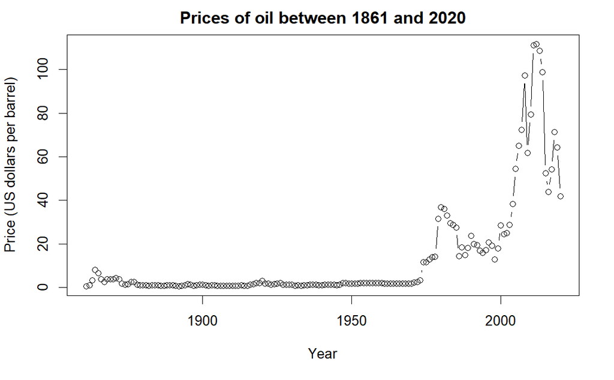

```r
# Plot year vs oil price
plot(oil.df$Year, oil.df$Price, type = 'b', xlab = 'Year', ylab = 'Price (US dollars per barrel)', main = 'Prices of oil between 1861 and 2020')
```

2.3. Which is the highest price in history? When did it occur?

```r
# Find year with maximum price
cat('Maximum price of oil from 1861 to 2020 was of', round(oil.df$Price[which.max(oil.df$Price)],digits=2), 'US dollars per barrell in the year', oil.df$Year[which.max(oil.df$Price)],'.')
```

```
Maximum price of oil from 1861 to 2020 was of 111.67 US dollars per barrell in the year 2012 .
```

2.4. Plot the derivative of the curve, simply evaluated with the finite difference formula (forward derivative).

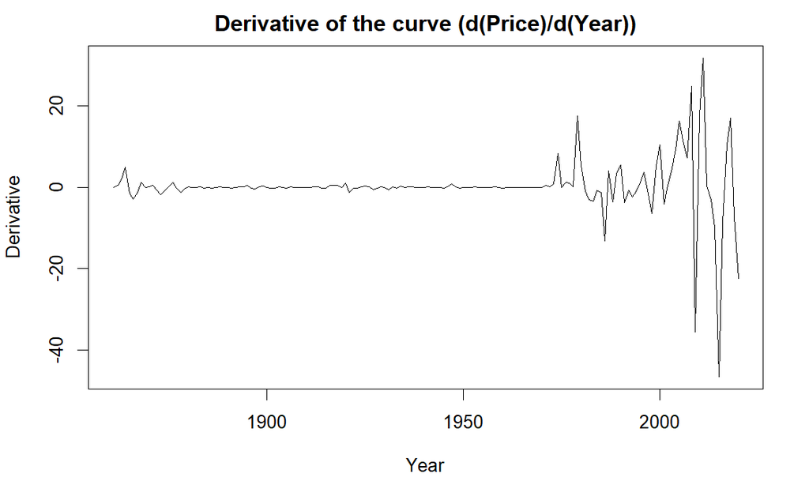

```r
der <- 0
for (i in 1:(length(oil.df$Price)-1))
  der <- append(der, oil.df$Price[i+1] - oil.df$Price[i])

plot(oil.df$Year,der, type = 'l', main = 'Derivative of the curve (d(Price)/d(Year))', xlab = 'Year', ylab = 'Derivative')
```

## Exercise 3 - World Coal Production

3.1. Write R code that is able to read the file and import it in a tibble structure.

```r
#Load the data
coal_df <- readxl::read_xlsx("/Users/cmart/Documents/Universidad/Master/Second Semester/Advanced Statistics/Labs/coal-production-by-country.xlsx", col_names = TRUE)

coal_df
```

| Entity | Code | Year | Coal production (TWh) |
| --- | --- | --- | --- |
| Afghanistan | AFG | 1900 | 0 |
| Afghanistan | AFG | 1901 | 0 |
| Afghanistan | AFG | 1902 | 0 |
| Afghanistan | AFG | 1903 | 0 |
| Afghanistan | AFG | 1904 | 0 |
| Afghanistan | AFG | 1905 | 0 |
| Afghanistan | AFG | 1906 | 0 |
| Afghanistan | AFG | 1907 | 0 |
| Afghanistan | AFG | 1908 | 0 |
| Afghanistan | AFG | 1909 | 0 |

[output cut: 990 more lines]

3.2. Count the number of countries available in the file and produce a barplot with the number of entries for each country.

```r
# Find the number of different countries in our data frame
n.countries <- length(unique(coal_df$Entity))

cat('Countries in the database:', n.countries)
```

```
Countries in the database: 200
```

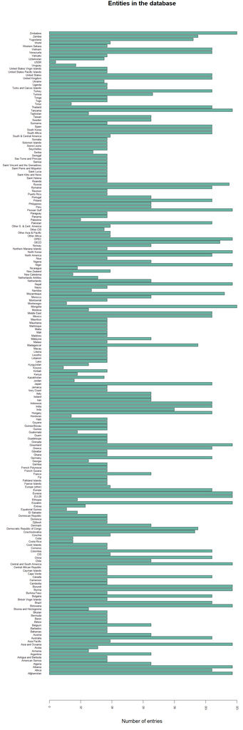

```r
# The table function provides the number of counts for each country
par(mar=c(5,8,1,1), cex.axis=0.5)
barplot(table(coal_df$Entity), horiz = TRUE,col="#69b3a2", las = 2,
        main = 'Entities in the database',
        xlab = 'Number of entries')
```

3.3. Selecting only the year after 1970, determine the total integrated production for each country and print the top 5 Countries with highest coal productions.

```r
# Select only the rows corresponding to years after 1970
coal.1970 <- coal_df[coal_df$Year>1970,]

# Change the name of column for easier handling
colnames(coal.1970)[4] <- 'coal_production'

# Sum the production over the years for each entity
total.production <- ddply(coal.1970, .(Entity), summarise, coal_total_prod=sum(as.numeric(coal_production)))

# Sort the data by production quantity
total.production <- total.production[order(-total.production$coal_total_prod),]

# By observing the data we infer the result:
#total_production
cat("The 5 countries with highest coal productions are: China, US, Russia, Australia and India")
```

```
The 5 countries with highest coal productions are: China, US, Russia, Australia and India
```

```r
total.production <- total.production[total.production$Entity %in% c("China" , "Russia", "United States", "Australia", "India"),]
colnames(total.production)[2] <- 'Total coal production (TWh)'
total.production
```

|  | Entity | Total coal production (TWh) |
| --- | --- | --- |
| 32 | China | 373925122 |
| 166 | United States | 199506016 |
| 135 | Russia | 93165048 |
| 10 | Australia | 77139808 |
| 77 | India | 69817117 |

```r
NA
```

3.4. For the 5 top Countries, create a plot of production as a function of time.

```r
# Select the appropiate rows from the dataframe
top5.df <- coal.1970[coal.1970$Entity %in% c("China" , "Russia", "United States", "Australia", "India"),]
top5.df
```

| Entity | Code | Year | coal_production |
| --- | --- | --- | --- |
| Australia | AUS | 1981 | 788572 |
| Australia | AUS | 1982 | 804955 |
| Australia | AUS | 1983 | 838741 |
| Australia | AUS | 1984 | 880918 |
| Australia | AUS | 1985 | 1074347 |
| Australia | AUS | 1986 | 1142.86 |
| Australia | AUS | 1987 | 1193669 |
| Australia | AUS | 1988 | 1173294 |
| Australia | AUS | 1989 | 1274679 |
| Australia | AUS | 1990 | 1334602 |

[output cut: 190 more lines]

```r
# Plot production as a function of time
plot(top5.df$Year[top5.df$Entity == "China"], top5.df$coal_production[top5.df$Entity == "China"] , type = 'p', col = 'red', xlab = 'Year', ylab = 'Coal Production (TWh)', main = 'Coal Production between 1970 and 2020')

lines(top5.df$Year[top5.df$Entity == "United States"], top5.df$coal_production[top5.df$Entity == "United States"] , type ='p', col = 'blue')
```

```r
lines(top5.df$Year[top5.df$Entity == "India"], top5.df$coal_production[top5.df$Entity == "India"] , type ='p', col = 'orange')

lines(top5.df$Year[top5.df$Entity == "Russia"], top5.df$coal_production[top5.df$Entity == "Russia"] , type ='p', col = 'black')
```

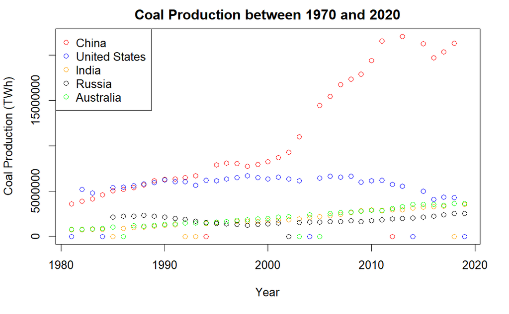

```r
lines(top5.df$Year[top5.df$Entity == "Australia"], top5.df$coal_production[top5.df$Entity == "Australia"] , type ='p', col = 'green')

legend("topleft", legend = c("China", "United States", "India", "Russia", "Australia"),
       col = c("red", "blue", "orange", "black", "green"), pch = 1)
```

3.5. Generate a plot with the cumulative sum of the World’s coal production over the years.

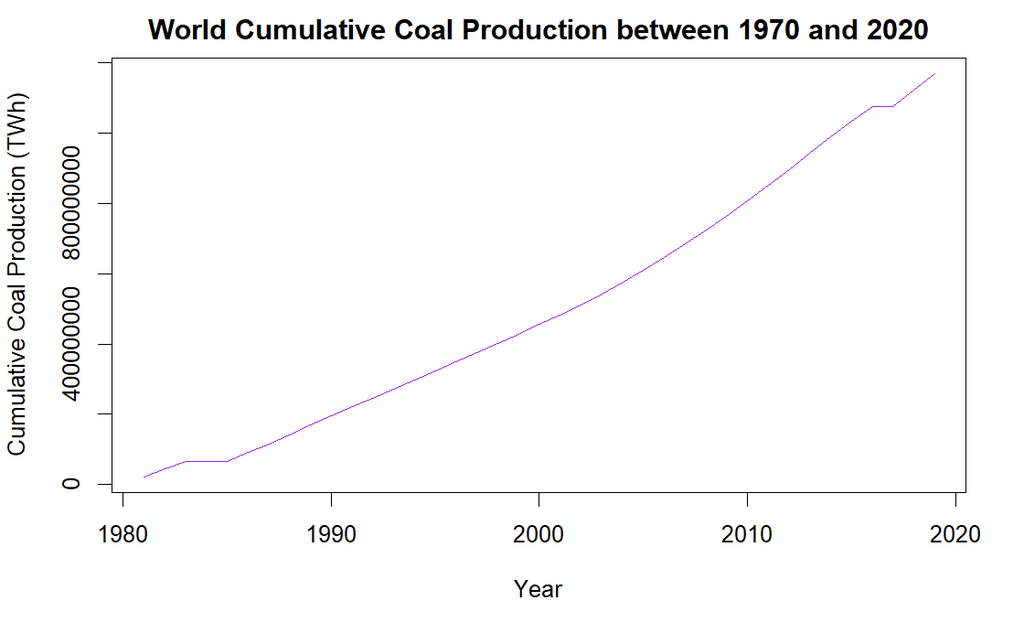

```r
# Create a data set with just the World Data
world.coal <- coal.1970[coal.1970$Entity == "World",]

# Perform the cumulative sum
world.coalc <- ddply(world.coal, .(Entity), summarise, cum=cumsum(as.numeric(coal_production)))

# PLot the results
plot(world.coal$Year, world.coalc$cum , type = 'l', col = 'purple', xlab = 'Year', ylab = 'Cumulative Coal Production (TWh)', main = 'World Cumulative Coal Production between 1970 and 2020')
```

## Exercise 4 - Covid19 Vaccine Data

```r
# Upload the data

vacc.manufacturer <- read.csv("/Users/cmart/Documents/Universidad/Master/Second Semester/Advanced Statistics/Labs/vaccinations-by-manufacturer.csv", header = TRUE, sep = ',')

#See columns we have and size of dataframe
names(vacc.manufacturer)
```

```
[1] "location"           "date"               "vaccine"            "total_vaccinations"
```

```r
dim(vacc.manufacturer)
```

```
[1] 35810     4
```

```r
#See the types of vaccines we have
unique(vacc.manufacturer$vaccine)
```

```
 [1] "Moderna"            "Oxford/AstraZeneca" "Sinopharm/Beijing"  "Sputnik V"
 [5] "CanSino"            "Pfizer/BioNTech"    "Johnson&Johnson"    "Novavax"
 [9] "Sinovac"            "Covaxin"
```

```r
# We need to transform the date column to a R dateclass
vacc.manufacturer$date <- as.Date(vacc.manufacturer$date, format = "%Y-%m-%d")
```

4.1. filter the original tibble by selecting the following countries: Italy.

```r
# Select only Italy's vaccination data
vacc.italy <- vacc.manufacturer[vacc.manufacturer$location == "Italy",]

vacc.italy
```

|  | location | date | vaccine | total_vaccinations |
| --- | --- | --- | --- | --- |
| 14868 | Italy | 2020-12-27 | Moderna | 2 |
| 14869 | Italy | 2020-12-27 | Pfizer/BioNTech | 7347 |
| 14870 | Italy | 2020-12-28 | Moderna | 6 |
| 14871 | Italy | 2020-12-28 | Pfizer/BioNTech | 8848 |
| 14872 | Italy | 2020-12-29 | Moderna | 11 |
| 14873 | Italy | 2020-12-29 | Pfizer/BioNTech | 9942 |
| 14874 | Italy | 2020-12-30 | Moderna | 22 |
| 14875 | Italy | 2020-12-30 | Pfizer/BioNTech | 14816 |
| 14876 | Italy | 2020-12-31 | Pfizer/BioNTech | 40763 |
| 14877 | Italy | 2021-01-01 | Moderna | 27 |

[output cut: 990 more lines]

4.2. Plot the number of vaccines given as a function of time for the different vaccine manufacturer.

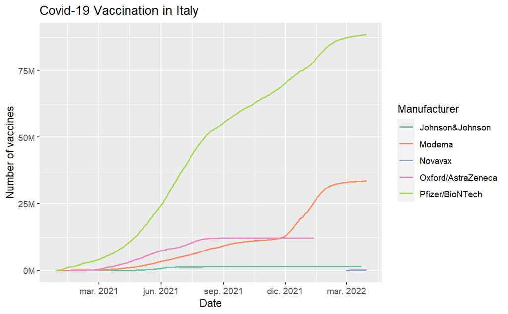

```r
# Plot
options(scipen=999)
g.italy <- ggplot(vacc.italy, aes(x = date, y = total_vaccinations)) +
  geom_line(aes(col=vaccine), size=0.7) + xlab('Date') +
  ylab('Number of vaccines') + ggtitle('Covid-19 Vaccination in Italy') +
  scale_colour_brewer(palette = "Set2") +
  scale_x_date(date_breaks = '3 months', date_labels = '%b %Y') +
  scale_y_continuous(labels = function(x){paste0((x/1000000), 'M')}) +
  guides(color=guide_legend("Manufacturer", order = 5))

plot(g.italy)
```

4.3. From the same tibble plot the total number of vaccines shot per day in Italy.

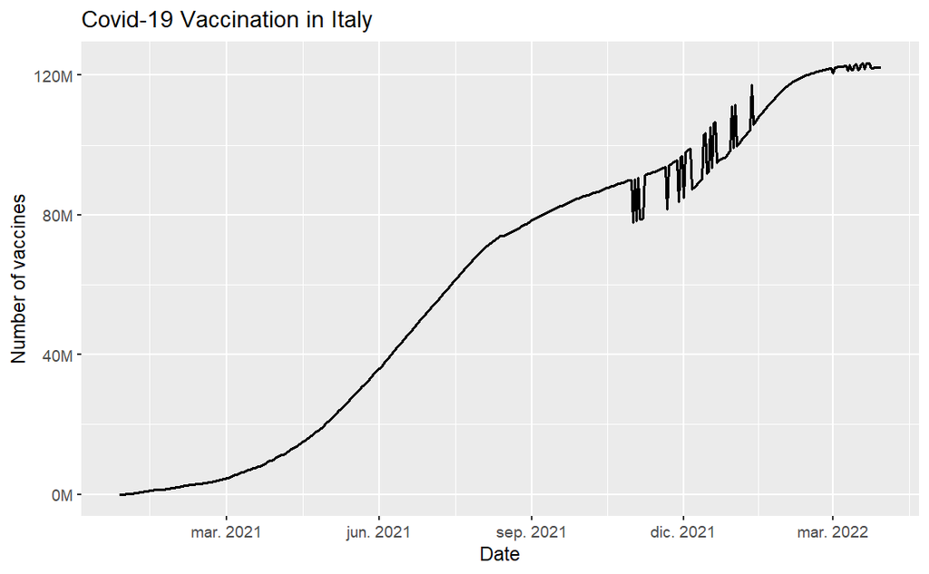

```r
# Sum the total vaccinations of different manufacturers for each day
vacc.day <- ddply(vacc.italy, .(date), summarise, total_vaccs=sum(as.numeric(total_vaccinations)))

#Plot
italy.total <- ggplot(vacc.day, aes(x = date, y = total_vaccs)) +
  geom_line(size=0.7) +
  xlab('Date') + ylab('Number of vaccines') +
  ggtitle('Covid-19 Vaccination in Italy') +
  scale_x_date(date_breaks = '3 months', date_labels = '%b %Y') +
  scale_y_continuous(labels = function(x){paste0((x/1000000), 'M')})

plot(italy.total)
```

4.4. Do the same exercise for the following countries: Germany and United States of America

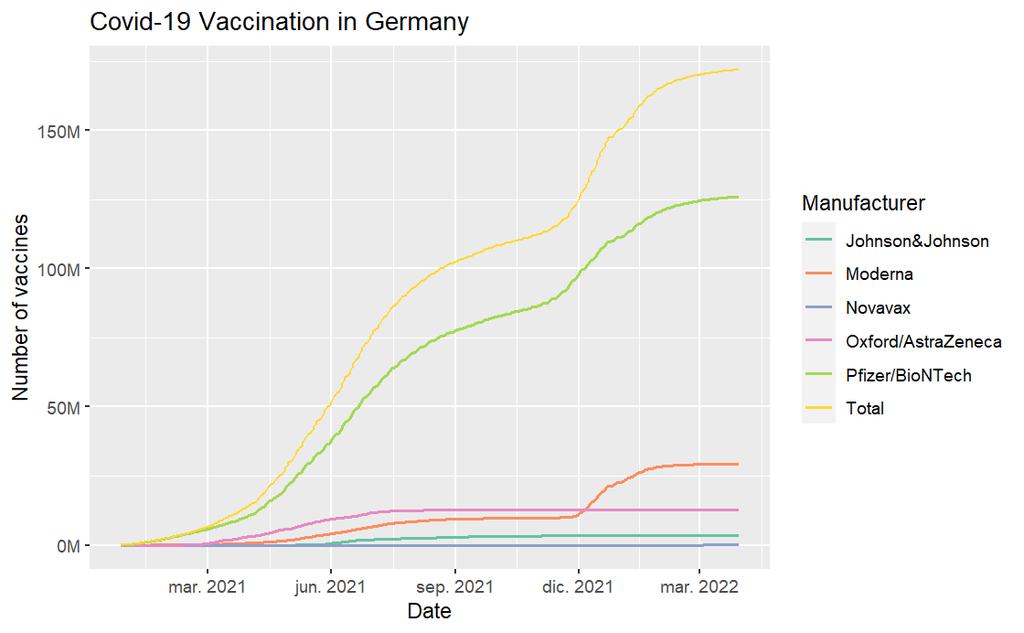

```r
# Germany
vacc.germany <- vacc.manufacturer[vacc.manufacturer$location == "Germany",]

# Vaccs per day
vacc.dayg <- ddply(vacc.germany, .(date), summarise, total_vaccs=sum(as.numeric(total_vaccinations)))

# Plot
g.germany <- ggplot() +
  geom_line(data = vacc.germany, aes(x = date, y = total_vaccinations, col=vaccine), size=0.7) +
  geom_line(data = vacc.dayg, aes(x = date, y = total_vaccs, col = "Total")) +
  xlab('Date') + ylab('Number of vaccines') +
  ggtitle('Covid-19 Vaccination in Germany') +
  scale_colour_brewer(palette = "Set2") +
  scale_x_date(date_breaks = '3 months', date_labels = '%b %Y') +
  scale_y_continuous(labels = function(x){paste0((x/1000000), 'M')}) +
  guides(color=guide_legend("Manufacturer", order = 5))

plot(g.germany)
```

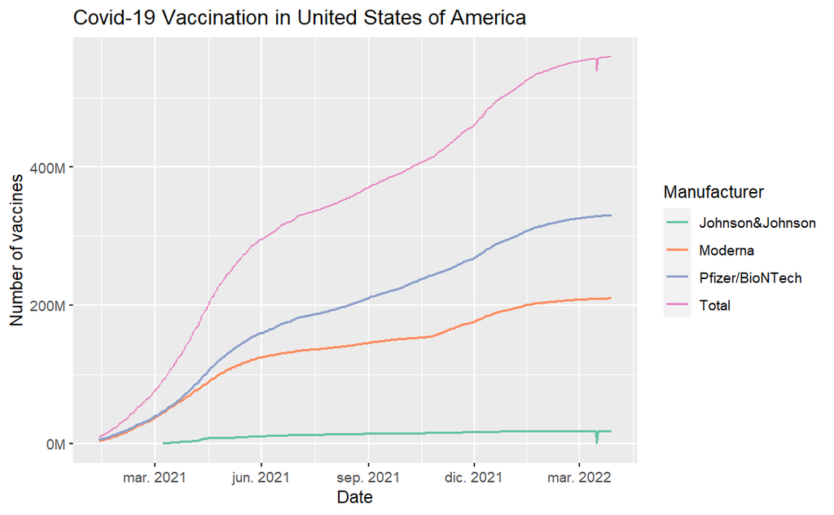

```r
# United States
vacc.us <- vacc.manufacturer[vacc.manufacturer$location == "United States",]

# Vaccs per day
vacc.dayus <- ddply(vacc.us, .(date), summarise, total_vaccs=sum(as.numeric(total_vaccinations)))

g.us <- ggplot() +
  geom_line(data = vacc.us, aes(x = date, y = total_vaccinations, col=vaccine), size=0.7) +
  geom_line(data = vacc.dayus, aes(x = date, y = total_vaccs, col = "Total")) +
  xlab('Date') + ylab('Number of vaccines') +
  ggtitle('Covid-19 Vaccination in United States of America') +
  scale_colour_brewer(palette = "Set2") +
  scale_x_date(date_breaks = '3 months', date_labels = '%b %Y') +
  scale_y_continuous(labels = function(x){paste0((x/1000000), 'M')}) +
  guides(color=guide_legend("Manufacturer"))

plot(g.us)
```

With the other vaccination data set:

```r
# Upload the data

vacc.df <- read.csv("/Users/cmart/Documents/Universidad/Master/Second Semester/Advanced Statistics/Labs/vaccinations.csv", header = TRUE, sep = ',')

#See data features we have and size of dataframe
names(vacc.df)
```

```
 [1] "location"                            "iso_code"
 [3] "date"                                "total_vaccinations"
 [5] "people_vaccinated"                   "people_fully_vaccinated"
 [7] "total_boosters"                      "daily_vaccinations_raw"
 [9] "daily_vaccinations"                  "total_vaccinations_per_hundred"
[11] "people_vaccinated_per_hundred"       "people_fully_vaccinated_per_hundred"
[13] "total_boosters_per_hundred"          "daily_vaccinations_per_million"
[15] "daily_people_vaccinated"             "daily_people_vaccinated_per_hundred"
```

```r
dim(vacc.df)
```

```
[1] 92207    16
```

```r
# We need to transform the date column to a R dateclass
vacc.df$date <- as.Date(vacc.df$date, format = "%Y-%m-%d")
```

4.5. Selecting all the European countries in the tibble, plot the number of daily vaccinations per million as a function of date.

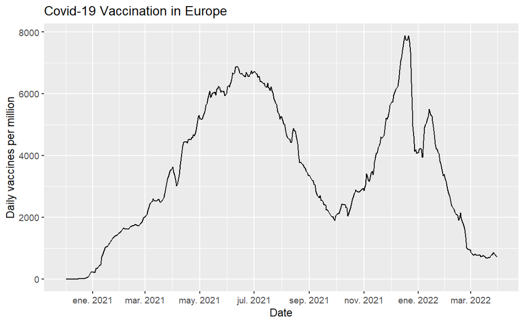

```r
# Select only vaccination in Europe
vacc.eu <- vacc.df[vacc.df$location == "Europe",]

g.eu <- ggplot(data = vacc.eu, aes(x = date, y = daily_vaccinations_per_million)) +
  geom_line() +
  xlab('Date') + ylab('Daily vaccines per million') +
  ggtitle('Covid-19 Vaccination in Europe') +
  scale_x_date(date_breaks = '2 months', date_labels = '%b %Y')

plot(g.eu)
```

4.6. Study the data structure and produce few relevant plots of your taste.

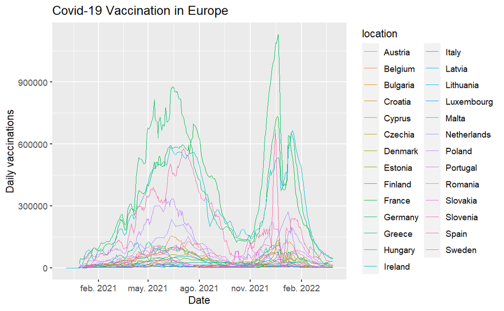

```r
# Lets find out how they vaccination is distributed among UE countries
UE.countries <- c('Austria', 'Belgium', 'Bulgaria', 'Croatia', 'Cyprus', 'Czechia', 'Denmark', 'Estonia', 'Finland', 'France', 'Germany', 'Greece', 'Hungary', 'Ireland', 'Italy', 'Latvia', 'Lithuania', 'Luxembourg', 'Malta', 'Netherlands', 'Poland', 'Portugal', 'Romania', 'Slovakia', 'Slovenia', 'Spain', 'Sweden')

vacc.UE <- vacc.df[vacc.df$location %in% UE.countries,]

g.detail <- ggplot(data = vacc.UE, aes(x = date, y = daily_vaccinations)) +
  geom_line(aes(col = location), size=0.4) +
  xlab('Date') + ylab('Daily vaccinations') +
  ggtitle('Covid-19 Vaccination in Europe') +
  scale_x_date(date_breaks = '3 months', date_labels = '%b %Y')


plot(g.detail)
```

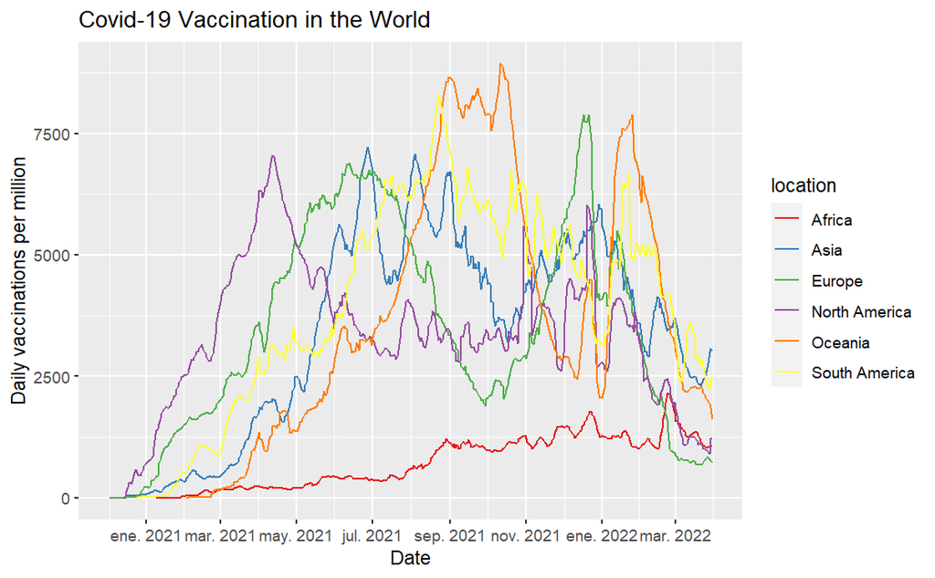

```r
# Observe vaccinations by continent
vacc.continent <- vacc.df[vacc.df$location %in% c("Europe" , "Asia", "South America", "North America", "Oceania", "Africa"),]

g.detail <- ggplot(vacc.continent, aes(x = date, y = daily_vaccinations_per_million)) +
  geom_line(aes(col = location)) +
  xlab('Date') + ylab('Daily vaccinations per million') +
  ggtitle('Covid-19 Vaccination in the World') +
  scale_x_date(date_breaks = '2 months', date_labels = '%b %Y') +
  scale_colour_brewer(palette = "Set1")


plot(g.detail)
```